# Correlations between Stock Performance and Google Search Trends

### James Riley Wilburn

The S&P 500 is a collection of 500 companies with the highest market capitalization. Market capitalization (market cap) is the price of a given company's stock multiplied by the total number of shares of that stock that are publicly traded. Market cap is used as a measure for the general value of an entire company. In general, the S&P 500 is a collection of the 500 most currently valuable companies. More details on the S&P 500 can be found [here](https://www.wikiwand.com/en/S%26P_500_Index). The companies in the S&P 500 were chosen for this tutorial because there is generally a large amount of historical data available for companies of this size. It is also useful to know how to analyze financial in general because a significant portion of stock trading is now done algorithmically. Knowing how to interact with market data is a necessary skill to creating predictive market models.

The primary goal of this tutorial is identify potentially interesting correlations between financial data and various terms associated with each company. Search trend data is gathered from Google, while the financial data is sourced from Kaggle.

## Gathering the Data

Five years of S&P 500 daily data, including market open price, market close price, daily high, daily low, and daily volume (# of shares) traded was obtained from this source on [Kaggle](https://www.kaggle.com/camnugent/sandp500). This data already in a nice comma separated value (CSV) format. A CSV file of the member companies of the S&P 500, their stock ticker, and their general industry category from [DataHub](https://datahub.io/core/s-and-p-500-companies-financials) is also used to categorize the companies by industry. As the S&P 500 changes membership occasionally and the two CSV files have differing ages, the sets of companies they contain are slightly different. For the purposes of this tutorial, the intersection of these two sets will be used.

```python
import pandas as pd

def head(df):
    return (
        df.iloc[:min(5, len(df))]
        .style
        .format(
            {
                "market_cap": lambda x: "${0:0.2f} B".format(x),
                "volume": lambda x: "{0:0.2f} M".format(x/1e6)
            }
        )
    )
```

```python
companies = pd.read_csv("constituents-financials_csv.csv", index_col="Symbol")
companies.index.rename("symbol",inplace=True)
companies.rename(inplace=True, columns={"Name": "name", "Sector": "sector", "Market Cap":'market_cap'})
companies['market_cap'] = companies['market_cap'].apply(lambda x: x/1e9)
companies = companies.reindex(columns=['name', 'sector', 'market_cap'])
head(companies)
```

| symbol | name | sector | market_cap |
| --- | --- | --- | --- |
| MMM | 3M Company | Industrials | $138.72 B |
| AOS | A.O. Smith Corp | Industrials | $10.78 B |
| ABT | Abbott Laboratories | Health Care | $102.12 B |
| ABBV | AbbVie Inc. | Health Care | $181.39 B |
| ACN | Accenture plc | Information Technology | $98.77 B |

The above [Python 3](https://www.python.org/download/releases/3.0/) code uses [pandas](https://pandas.pydata.org/) library to display the S&P 500 member list data. The CSV is loaded into a [DataFrame](https://pandas.pydata.org/pandas-docs/version/0.21/generated/pandas.DataFrame.html) which is a nice wrapper around [numpy](http://www.numpy.org/) multidimensional arrays that allows for efficient operations over columns of data, in a similar manner to a database. The above code also renames the columns and sets symbol as an index for ease of use later. Indices allow for efficient search of the dataset, again similar to databases.

```python
stock_data = pd.read_csv("all_stocks_5yr.csv", index_col=["Name", "date"])
stock_data.index.rename(["symbol", "timestamp"],inplace=True)
stock_data.index = stock_data.index.set_levels([
    stock_data.index.levels[0],
    pd.to_datetime(stock_data.index.levels[1]),
])
head(stock_data)
```

| symbol | timestamp | open | high | low | close | volume |
| --- | --- | --- | --- | --- | --- | --- |
| AAL | 2013-02-08 00:00:00 | 15.07 | 15.12 | 14.63 | 14.75 | 8.41 M |
|  | 2013-02-11 00:00:00 | 14.89 | 15.01 | 14.26 | 14.46 | 8.88 M |
|  | 2013-02-12 00:00:00 | 14.45 | 14.51 | 14.1 | 14.27 | 8.13 M |
|  | 2013-02-13 00:00:00 | 14.3 | 14.94 | 14.25 | 14.66 | 10.26 M |
|  | 2013-02-14 00:00:00 | 14.94 | 14.96 | 13.16 | 13.99 | 31.88 M |

The above code loads all the financial data into a DataFrame as demonstrated before. As before, the columns are also renamed to be consistent. Unlike before, additional processing is done to convert the timestamps to proper pandas datetime instances.

### Google Search Data

Unfortunately, google search trend data is not easily gatherable with python. At the time of writing, the python Google Trends API library pytrends is not functioning properly, possibly because the Google Trends API has been updated more recently than that library. Instead I had to use the google-trends-api NodeJS library. [NodeJS](https://nodejs.org/en/) is a platform that allows execution of JavaScript on the server side, rather than solely in a browser. The following code gathers [Google Trends](https://trends.google.com/trends/?geo=US) data from their *unofficial* API, so the following instructions may be incorrect in the near future.

```
// imports
const googleTrends = require("google-trends-api");
const parse = require("csv-parse/lib/sync");
const fs = require("fs");
const path = require("path");

// gather search data from Google Trends API
async function searchData(word) {
  let results = await googleTrends.interestOverTime({
    keyword: word,
    startTime: new Date("2013-02-08"),
    endTime: new Date("2018-02-08")
  });
  try {
    return {
      word: word,
      timeline: JSON.parse(results).default.timelineData.map(p => ({
        time: p.time,
        value: p.value[0]
      }))
    };
  } catch {
    console.error(results);
  }
}

// gather and tag Google Trend data for a list of words
async function gather(list) => {
  var results = [];
  for (i in list) {
    const word = list[i];
    await sleep(500);
    const data = await searchData(word);
    results.push(data);
    console.error(word);
  }
  return results;
};

// Sleep for ms milliseconds
function sleep(ms) {
  return new Promise(resolve => setTimeout(resolve, ms));
}

// Read S&P 500 members list as a string
const wordData = fs.readFileSync(
  path.join(__dirname, "constituents-financials_csv.csv"),
  "utf8"
);

// Parse S&P 500 members list into an object
const wordList = parse(wordData, {
  columns: true,
  skip_empty_lines: true
});

//Split S&P members list into its component columns
const symbols = wordList.map(x => x.Symbol);
const names = wordList.map(x => x.Name);
const sectors = [...new Set(wordList.map(x => x.Sector))];


// Gather and write Google Trends data to json files
(async () => {
  fs.writeFileSync("symbols.json", JSON.stringify(await gather(symbols)));
  fs.writeFileSync("names.json", JSON.stringify(await gather(names)));
  fs.writeFileSync("sectors.json", JSON.stringify(await gather(sectors)));
})();
```

The above code reads the S&P 500 companies list, then for each stock symbol, company name, and industry name in the list, it gathers Google Search trend data for the same 5 year period as the financial data. It outputs the gathered data as JSON documents. [JSON](https://www.json.org/) is a textual dataformat which is easily human readable and more structured than CSV.

### Google Search Data in Python

The JSON documents now need to be imported into python and processed into a DataFrame. Unfortunately, naively running `pd.read_json` results in an improperly formatted DataFrame.

```python
df = pd.read_json("symbols.json", orient="columns")
df.head()
```

|  | timeline | word |
| --- | --- | --- |
| 0 | [{'time': '1360454400', 'value': 17}, {'time':... | MMM |
| 1 | [{'time': '1360454400', 'value': 59}, {'time':... | AOS |
| 2 | [{'time': '1360454400', 'value': 85}, {'time':... | ABT |
| 3 | [{'time': '1360454400', 'value': 20}, {'time':... | ABBV |
| 4 | [{'time': '1360454400', 'value': 87}, {'time':... | ACN |

This DataFrame is very messy and basically useless in this format. It needs to be processed more extensively to properly extract the desired columns in a useable format.

```python
search_trends_symbol = pd.concat(
    map(
        lambda x: x[1],
        pd.read_json("symbols.json", orient="columns").apply(
            lambda row: pd.DataFrame.from_records(
                # Iterate over all of the timeline data
                map(
                    lambda t: { # t is a timeline row of the form {time, value}
                        "symbol": row['word'],
                        # Converts the unix timestamp to a real datetime
                        "timestamp":pd.to_datetime(t['time'], unit='s').floor('d'),
                        "frequency":t['value']
                    },
                    row.timeline,
                ) ,
                index=["symbol", "timestamp"]
            ) if len(row.timeline) else None,
            axis=1,
        ).iteritems(),
    )
)

head(search_trends_symbol)
```

| symbol | timestamp | frequency |
| --- | --- | --- |
| MMM | 2013-02-10 00:00:00 | 17 |
|  | 2013-02-17 00:00:00 | 18 |
|  | 2013-02-24 00:00:00 | 17 |
|  | 2013-03-03 00:00:00 | 18 |
|  | 2013-03-10 00:00:00 | 18 |

The above code processes the symbols JSON document and formats so that it can be digested into a pandas DataFrame. Essentially, for each of the stock symbols in the improper DataFrame above, it creates a DataFrame with columns `timestamp, frequency, search_term`, indexd on search_term and timestamp. Then it concatenates each of the new DataFrames into a complete DataFrame. The `if len(row.timeline) else None` ensures that the DataFrame concatenation does not break when there is no timeline data for the search term. This happens when the term is too specific for google to record its trends, which happens for some of the longer company names. The timestamps are rounded to the nearest day so that they can be compared for exact equality. This greatly simplifies processing later.

The same processing needs to be done on the company names JSON document and the industry names JSON document.

```python
search_trends_name = pd.concat(
    map(
        lambda x: x[1],
        pd.read_json("names.json", orient="columns").apply(
            lambda row: pd.DataFrame.from_records(
                map(
                    lambda t: {
                        "name": row['word'],
                        "timestamp":pd.to_datetime(t['time'], unit='s').floor('d'),
                        "frequency":t['value']
                    },
                    row.timeline,
                ),
                index=["name", "timestamp"]
            ) if len(row.timeline) else None,
            axis=1,
        ).iteritems(),
    )
)

head(search_trends_name)
```

| name | timestamp | frequency |
| --- | --- | --- |
| 3M Company | 2013-02-10 00:00:00 | 70 |
|  | 2013-02-17 00:00:00 | 66 |
|  | 2013-02-24 00:00:00 | 67 |
|  | 2013-03-03 00:00:00 | 60 |
|  | 2013-03-10 00:00:00 | 79 |

```python
search_trends_sector = pd.concat(
    map(
        lambda x: x[1],
        pd.read_json("sectors.json", orient="columns").apply(
            lambda row: pd.DataFrame.from_records(
                map(
                    lambda t: {
                        "sector": row['word'],
                        "timestamp":pd.to_datetime(t['time'], unit='s').floor('d'),
                        "frequency":t['value']
                    },
                    row.timeline,
                ),
                index=["sector", "timestamp"]
            )if len(row.timeline) else None,
            axis=1,
        ).iteritems(),
    )
)

head(search_trends_sector)
```

| sector | timestamp | frequency |
| --- | --- | --- |
| Industrials | 2013-02-10 00:00:00 | 53 |
|  | 2013-02-17 00:00:00 | 44 |
|  | 2013-02-24 00:00:00 | 46 |
|  | 2013-03-03 00:00:00 | 43 |
|  | 2013-03-10 00:00:00 | 39 |

## Preprocessing the Data

Before the raw data is ready for analysis, it must be preprocessed. In this case, the appopriate terms and frequency data must be mapped to the financial data in order to do the correlations between them. In order to match the timestamps between the stock ticker data and the search trends data, the stock data weeks must be condensed into one data point per week per ticker from the original daily datapoints. This will also tend to reduce noise in the data and minimize weekly fluctuations.

```python
stock_data = stock_data.groupby(['symbol', pd.Grouper(level='timestamp', freq='W-SUN')]).mean()

head(stock_data)
```

| symbol | timestamp | open | high | low | close | volume |
| --- | --- | --- | --- | --- | --- | --- |
| A | 2013-02-10 00:00:00 | 45.07 | 45.35 | 45 | 45.08 | 1.82 M |
|  | 2013-02-17 00:00:00 | 44.598 | 44.878 | 44.04 | 44.16 | 5.17 M |
|  | 2013-02-24 00:00:00 | 42.255 | 42.545 | 41.8713 | 42.17 | 3.69 M |
|  | 2013-03-03 00:00:00 | 41.332 | 41.891 | 40.898 | 41.48 | 3.99 M |
|  | 2013-03-10 00:00:00 | 42.78 | 43.178 | 42.518 | 42.842 | 2.88 M |

```python
search_trends = (
    search_trends_symbol
    .join(companies, on='symbol')
    .rename(columns={'frequency': 'symbol_frequency'})
    .join(
        (search_trends_name
        .rename(columns={'frequency': 'name_frequency'})),
        on=['name', 'timestamp'])
    .join(
        (search_trends_sector
        .rename(columns={'frequency': 'sector_frequency'})),
        on=['sector', 'timestamp'])
).reindex(
    columns=['name', 'sector', 'symbol_frequency', 'name_frequency', 'sector_frequency']
).fillna(0)

head(search_trends.loc['AAPL'])
```

| timestamp | name | sector | symbol_frequency | name_frequency | sector_frequency |
| --- | --- | --- | --- | --- | --- |
| 2013-02-10 00:00:00 | Apple Inc. | Information Technology | 63 | 52 | 93 |
| 2013-02-17 00:00:00 | Apple Inc. | Information Technology | 48 | 68 | 95 |
| 2013-02-24 00:00:00 | Apple Inc. | Information Technology | 54 | 66 | 96 |
| 2013-03-03 00:00:00 | Apple Inc. | Information Technology | 63 | 56 | 95 |
| 2013-03-10 00:00:00 | Apple Inc. | Information Technology | 52 | 70 | 95 |

The above code joins all of the search data across symbols, company names, and sectors using the company DataFrame which contains a mapping between all of those values. For those that know SQL, the above is equivalent to the following:

```
SELECT
    symbols.symbols as symbol,
    symbols.timestamp as timestamp,
    companies.name as name,
    companies.sector as sector,
    companies.market_cap as market_cap,
    symbols.frequency as symbol_frequency,
    names.frequency as name_frequency,
    sectors.frequency as sector_frequency
FROM search_trends_symbol as symbols
JOIN companies ON companies.symbols = symbols.symbols
JOIN names ON names.symbols = companies.symbols AND names.timestamp = symbols.timestamp
JOIN names ON sectors.symbols = companies.symbols AND sectors.timestamp = symbols.timestamp
```

Essentially, all the matching data between the columns is lined up, and a new DataFrame is constructed from all of the combined data.

All of the NaN frequency values correspond to search queries which are too infrequent to be recorded by Google Trends, so they are replaced by 0. Now the search data is ready to be joined to the financial data.

```python
df = (stock_data.join(
    search_trends,
    on=['symbol', 'timestamp']
))

head(df)
```

| symbol | timestamp | open | high | low | close | volume | name | sector | symbol_frequency | name_frequency | sector_frequency |
| --- | --- | --- | --- | --- | --- | --- | --- | --- | --- | --- | --- |
| A | 2013-02-10 00:00:00 | 45.07 | 45.35 | 45 | 45.08 | 1.82 M | Agilent Technologies Inc | Health Care | 85 | 39 | 54 |
|  | 2013-02-17 00:00:00 | 44.598 | 44.878 | 44.04 | 44.16 | 5.17 M | Agilent Technologies Inc | Health Care | 88 | 52 | 52 |
|  | 2013-02-24 00:00:00 | 42.255 | 42.545 | 41.8713 | 42.17 | 3.69 M | Agilent Technologies Inc | Health Care | 89 | 39 | 56 |
|  | 2013-03-03 00:00:00 | 41.332 | 41.891 | 40.898 | 41.48 | 3.99 M | Agilent Technologies Inc | Health Care | 87 | 26 | 55 |
|  | 2013-03-10 00:00:00 | 42.78 | 43.178 | 42.518 | 42.842 | 2.88 M | Agilent Technologies Inc | Health Care | 89 | 25 | 54 |

The above code simply joins the stock data and search trends data by symbol and timestamp. Due to slight inconsistencies around the endpoints of the timeranges in the DataFrames, there are some missing values. These can be discarded because they represent a relatively small number of the overall dataset and are missing due to inherent structure in the data that was collected, and probably not caused by some kind of hidden variable affecting both of the datasets.

```python
print(len(df), len(df) - len(df.dropna())) # Number of rows containing NaN in the DataFrame
df = df.dropna()
```

```
128834 2333
```

## Exploration

Now that all the data is cleaned and joined, it can be analyzed. Before in depth analysis can be conducted, first we should try to narrow down what variables are useful to compare. In this case, a fast way to get a general overview of basic patterns is to run correlations between all of the columns. Pandas comes with a quick method on DataFrames to do this.

```python
stock_data_trends_corrs = df.corr().round(5)

stock_data_trends_corrs
```

|  | open | high | low | close | volume | symbol_frequency | name_frequency | sector_frequency |
| --- | --- | --- | --- | --- | --- | --- | --- | --- |
| open | 1.00000 | 0.99998 | 0.99997 | 0.99997 | -0.17299 | -0.01950 | 0.02842 | -0.08059 |
| high | 0.99998 | 1.00000 | 0.99994 | 0.99998 | -0.17275 | -0.01983 | 0.02849 | -0.08061 |
| low | 0.99997 | 0.99994 | 1.00000 | 0.99998 | -0.17337 | -0.01914 | 0.02838 | -0.08068 |
| close | 0.99997 | 0.99998 | 0.99998 | 1.00000 | -0.17307 | -0.01949 | 0.02845 | -0.08060 |
| volume | -0.17299 | -0.17275 | -0.17337 | -0.17307 | 1.00000 | -0.01650 | 0.08172 | 0.07793 |
| symbol_frequency | -0.01950 | -0.01983 | -0.01914 | -0.01949 | -0.01650 | 1.00000 | -0.02101 | 0.03218 |
| name_frequency | 0.02842 | 0.02849 | 0.02838 | 0.02845 | 0.08172 | -0.02101 | 1.00000 | 0.01598 |
| sector_frequency | -0.08059 | -0.08061 | -0.08068 | -0.08060 | 0.07793 | 0.03218 | 0.01598 | 1.00000 |

These values measure correlational strength. The values range from [1, -1] with 1 and -1 being strong positive correlations and strong negative correlations respectively. It turns out that accross the S&P 500, all of the price metrics correlate extremely strongly with one another. This is unsurprising considering they measure bounds on the same value. However, this means that in further analysis, it is pointless to include all of the price metrics. Instead, a we can calculate a single metric from the price metrics without majorly affecting the data.

```python
df['price'] = df[['open','high','low','close']].mean(axis=1)
df = df.drop(columns=['open', 'high', 'low', 'close'])
df = df.reindex(columns=['price', 'volume', 'name', 'sector', 'symbol_frequency', 'name_frequency', 'sector_frequency'])

head(df)
```

| symbol | timestamp | price | volume | name | sector | symbol_frequency | name_frequency | sector_frequency |
| --- | --- | --- | --- | --- | --- | --- | --- | --- |
| A | 2013-02-10 00:00:00 | 45.125 | 1.82 M | Agilent Technologies Inc | Health Care | 85 | 39 | 54 |
|  | 2013-02-17 00:00:00 | 44.419 | 5.17 M | Agilent Technologies Inc | Health Care | 88 | 52 | 52 |
|  | 2013-02-24 00:00:00 | 42.2103 | 3.69 M | Agilent Technologies Inc | Health Care | 89 | 39 | 56 |
|  | 2013-03-03 00:00:00 | 41.4002 | 3.99 M | Agilent Technologies Inc | Health Care | 87 | 26 | 55 |
|  | 2013-03-10 00:00:00 | 42.8295 | 2.88 M | Agilent Technologies Inc | Health Care | 89 | 25 | 54 |

```python
stock_data_trends_corrs = df.corr().round(5)

stock_data_trends_corrs.head()
```

|  | price | volume | symbol_frequency | name_frequency | sector_frequency |
| --- | --- | --- | --- | --- | --- |
| price | 1.00000 | -0.17305 | -0.01949 | 0.02844 | -0.08062 |
| volume | -0.17305 | 1.00000 | -0.01650 | 0.08172 | 0.07793 |
| symbol_frequency | -0.01949 | -0.01650 | 1.00000 | -0.02101 | 0.03218 |
| name_frequency | 0.02844 | 0.08172 | -0.02101 | 1.00000 | 0.01598 |
| sector_frequency | -0.08062 | 0.07793 | 0.03218 | 0.01598 | 1.00000 |

The price <-> search category correlations look pretty similar to the other correlation matrix containing all of the original columns, but in a much more compact format. It is sort of interesting that volume traded negatively correlates with stock price accross the whole S&P 500. Let's see if that holds true on individual companies.

```python
df.groupby('symbol').corr().unstack().describe().stack()
```

|  |  | price | volume | symbol_frequency | name_frequency | sector_frequency |
| --- | --- | --- | --- | --- | --- | --- |
| count | price | 498.000000 | 498.000000 | 498.000000 | 429.000000 | 498.000000 |
|  | volume | 498.000000 | 498.000000 | 498.000000 | 429.000000 | 498.000000 |
|  | symbol_frequency | 498.000000 | 498.000000 | 498.000000 | 429.000000 | 498.000000 |
|  | name_frequency | 429.000000 | 429.000000 | 429.000000 | 429.000000 | 429.000000 |
|  | sector_frequency | 498.000000 | 498.000000 | 498.000000 | 429.000000 | 498.000000 |
| mean | price | 1.000000 | -0.205282 | 0.066210 | 0.007840 | -0.054284 |
|  | volume | -0.205282 | 1.000000 | 0.078963 | 0.053089 | 0.059731 |
|  | symbol_frequency | 0.066210 | 0.078963 | 1.000000 | 0.063868 | 0.081836 |
|  | name_frequency | 0.007840 | 0.053089 | 0.063868 | 1.000000 | 0.108987 |
|  | sector_frequency | -0.054284 | 0.059731 | 0.081836 | 0.108987 | 1.000000 |
| std | price | 0.000000 | 0.238481 | 0.397313 | 0.278596 | 0.318089 |
|  | volume | 0.238481 | 0.000000 | 0.186781 | 0.137100 | 0.132246 |
|  | symbol_frequency | 0.397313 | 0.186781 | 0.000000 | 0.232651 | 0.249453 |
|  | name_frequency | 0.278596 | 0.137100 | 0.232651 | 0.000000 | 0.184658 |
|  | sector_frequency | 0.318089 | 0.132246 | 0.249453 | 0.184658 | 0.000000 |
| min | price | 1.000000 | -0.822017 | -0.935319 | -0.866536 | -0.871975 |
|  | volume | -0.822017 | 1.000000 | -0.457801 | -0.608860 | -0.430158 |
|  | symbol_frequency | -0.935319 | -0.457801 | 1.000000 | -0.700280 | -0.851595 |
|  | name_frequency | -0.866536 | -0.608860 | -0.700280 | 1.000000 | -0.418459 |
|  | sector_frequency | -0.871975 | -0.430158 | -0.851595 | -0.418459 | 1.000000 |
| 25% | price | 1.000000 | -0.379760 | -0.186907 | -0.134046 | -0.192202 |
|  | volume | -0.379760 | 1.000000 | -0.036588 | -0.020822 | -0.016142 |
|  | symbol_frequency | -0.186907 | -0.036588 | 1.000000 | -0.050389 | -0.046320 |
|  | name_frequency | -0.134046 | -0.020822 | -0.050389 | 1.000000 | 0.002284 |
|  | sector_frequency | -0.192202 | -0.016142 | -0.046320 | 0.002284 | 1.000000 |
| 50% | price | 1.000000 | -0.219452 | 0.083446 | -0.024976 | 0.003699 |
|  | volume | -0.219452 | 1.000000 | 0.060229 | 0.040032 | 0.066548 |
|  | symbol_frequency | 0.083446 | 0.060229 | 1.000000 | 0.039444 | 0.097998 |
|  | name_frequency | -0.024976 | 0.040032 | 0.039444 | 1.000000 | 0.075580 |
|  | sector_frequency | 0.003699 | 0.066548 | 0.097998 | 0.075580 | 1.000000 |
| 75% | price | 1.000000 | -0.065690 | 0.363545 | 0.126603 | 0.168734 |
|  | volume | -0.065690 | 1.000000 | 0.185326 | 0.119121 | 0.134347 |
|  | symbol_frequency | 0.363545 | 0.185326 | 1.000000 | 0.146150 | 0.229165 |
|  | name_frequency | 0.126603 | 0.119121 | 0.146150 | 1.000000 | 0.207053 |
|  | sector_frequency | 0.168734 | 0.134347 | 0.229165 | 0.207053 | 1.000000 |
| max | price | 1.000000 | 0.763612 | 0.909885 | 0.886283 | 0.756463 |
|  | volume | 0.763612 | 1.000000 | 0.814289 | 0.612869 | 0.561253 |
|  | symbol_frequency | 0.909885 | 0.814289 | 1.000000 | 0.847393 | 0.845899 |
|  | name_frequency | 0.886283 | 0.612869 | 0.847393 | 1.000000 | 0.854579 |
|  | sector_frequency | 0.756463 | 0.561253 | 0.845899 | 0.854579 | 1.000000 |

The above code, while it looks a bit intimidating, essentially runs correlations for each company separately, and the aggregates statistics each correlation type. Specifically, this tells us that there is a good degree of variation in the correlation between stock data and search data within a specific company. It also provides potentially interesting outliers to explore. especially for the companies close to the max or min correlation values for price and volume compared to search term stats.

It requires a bit more finangling to extract particular, interesting correlations from the thousands of computed correlations.

```python
import itertools

# Get a particular correlation for a pair of values
def corr(corrs, a, b):
    return corrs[a].apply(lambda x: x.loc[slice(None), b].sort_values(ascending=False))

correlations = (
    pd.DataFrame.from_records((
        {"symbol":symbol, "correlation": val, "financial_stat": a, "search_stat": b}
        for a,b in itertools.product(
            ['price'],
            ['symbol_frequency', 'name_frequency', 'sector_frequency'],
        )
        for (symbol, _), val in corr(
                df.groupby('symbol').corr().groupby('symbol'),
                a,
                b,
            ).iteritems()
        ),
    )
    .set_index(["symbol", "financial_stat", "search_stat"])
)
```

The above essentially extracts all of the interesing correlations by extracting each pair and the placing each correlation coefficient into a series with a 3-level index of the form (symbol, stat1, stat2).

Now that we can view specific correlations more easily, lets look at the extrema.

```python
correlations.nsmallest(10, 'correlation').join(companies, on='symbol')
```

| symbol | financial_stat | search_stat | correlation | name | sector | market_cap |
| --- | --- | --- | --- | --- | --- | --- |
| HON | price | symbol_frequency | -0.935319 | Honeywell Int'l Inc. | Industrials | 114.422169 |
| GOOGL | price | symbol_frequency | -0.898247 | Alphabet Inc Class A | Information Technology | 733.823966 |
| AWK | price | sector_frequency | -0.871975 | American Water Works Company Inc | Utilities | 13.906146 |
| CRM | price | name_frequency | -0.866536 | Salesforce.com | Information Technology | 79.489115 |
| ACN | price | symbol_frequency | -0.862733 | Accenture plc | Information Technology | 98.765856 |
| CMS | price | sector_frequency | -0.861910 | CMS Energy | Utilities | 11.873961 |
| WEC | price | sector_frequency | -0.853938 | Wec Energy Group Inc | Utilities | 18.890297 |
| MRO | price | symbol_frequency | -0.849156 | Marathon Oil Corp. | Energy | 13.875005 |
| GOOG | price | symbol_frequency | -0.843799 | Alphabet Inc Class C | Information Technology | 728.535558 |
| LNT | price | sector_frequency | -0.835638 | Alliant Energy Corp | Utilities | 8.670163 |

```python
correlations.nlargest(10, 'correlation').join(companies, on='symbol')
```

| symbol | financial_stat | search_stat | correlation | name | sector | market_cap |
| --- | --- | --- | --- | --- | --- | --- |
| NVDA | price | symbol_frequency | 0.909885 | Nvidia Corporation | Information Technology | 138.652800 |
| NEE | price | symbol_frequency | 0.904326 | NextEra Energy | Utilities | 69.661178 |
| HII | price | symbol_frequency | 0.886802 | Huntington Ingalls Industries | Industrials | 10.628248 |
| RMD | price | name_frequency | 0.886283 | ResMed | Health Care | 13.233623 |
| HD | price | symbol_frequency | 0.860174 | Home Depot | Consumer Discretionary | 223.378633 |
| CB | price | symbol_frequency | 0.839356 | Chubb Limited | Financials | 68.424671 |
| AVGO | price | symbol_frequency | 0.836616 | Broadcom | Information Technology | 92.791975 |
| PNW | price | symbol_frequency | 0.836317 | Pinnacle West Capital | Utilities | 8.397610 |
| ESS | price | symbol_frequency | 0.815639 | Essex Property Trust, Inc. | Real Estate | 14.383525 |
| LRCX | price | symbol_frequency | 0.812985 | Lam Research | Information Technology | 27.967535 |

Interesting. [NVidia](https://www.nvidia.com/en-us/) stock price has a very strong positive correlation with how frequently its symbol is searched, while [Honeywell](https://www.honeywell.com/) has a very strong negative correlation with how frequently it is searched. Perhaps a plot would be enlightening?

## Visualizations

In order to construct the plot, the price data must be clamped between 0 and 100, otherwise the scales will not line up properly.

```python
df['normalized_price'] = (df
                          .groupby('symbol', group_keys=False)
                          .apply(lambda x: (100*x['price']/x['price'].max()))
                         )

df.head()
```

| symbol | timestamp | price | volume | name | sector | symbol_frequency | name_frequency | sector_frequency | normalized_price |
| --- | --- | --- | --- | --- | --- | --- | --- | --- | --- |
| A | 2013-02-10 | 45.125000 | 1824755.00 | Agilent Technologies Inc | Health Care | 85.0 | 39.0 | 54.0 | 61.166743 |
|  | 2013-02-17 | 44.419000 | 5165006.80 | Agilent Technologies Inc | Health Care | 88.0 | 52.0 | 52.0 | 60.209763 |
|  | 2013-02-24 | 42.210313 | 3689833.75 | Agilent Technologies Inc | Health Care | 89.0 | 39.0 | 56.0 | 57.215897 |
|  | 2013-03-03 | 41.400250 | 3985236.20 | Agilent Technologies Inc | Health Care | 87.0 | 26.0 | 55.0 | 56.117860 |
|  | 2013-03-10 | 42.829500 | 2878377.80 | Agilent Technologies Inc | Health Care | 89.0 | 25.0 | 54.0 | 58.055203 |

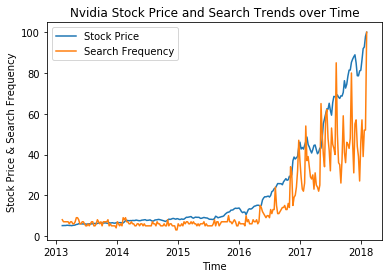

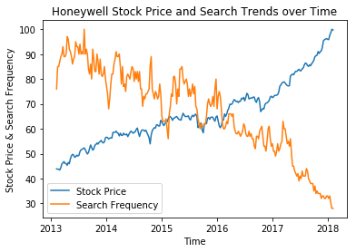

```python
%matplotlib inline

import matplotlib.pyplot as plt # Plotting library
import seaborn as sns

fig, axs = plt.subplots(ncols=1)

axs.set_title("Nvidia Stock Price and Search Trends over Time")
sns.lineplot(x='timestamp', y='normalized_price', data=df.xs('NVDA').reset_index(), ax=axs, label="Stock Price")
sns.lineplot(x='timestamp', y='symbol_frequency', data=df.xs('NVDA').reset_index(), ax=axs, label='Search Frequency')
axs.set_ylabel("Stock Price & Search Frequency")
axs.set_xlabel("Time")


fig, axs = plt.subplots(ncols=1)

axs.set_title("Honeywell Stock Price and Search Trends over Time")
sns.lineplot(x='timestamp', y='normalized_price', data=df.xs('HON').reset_index(), ax=axs, label="Stock Price")
sns.lineplot(x='timestamp', y='symbol_frequency', data=df.xs('HON').reset_index(), ax=axs, label='Search Frequency')
axs.set_ylabel("Stock Price & Search Frequency")
axs.set_xlabel("Time")
axs.legend()

_=_
```

The above plots are created using the [seaborn](https://seaborn.pydata.org/) plotting library, which is a nice wrapper around [matplotlib](https://matplotlib.org/), another, lower level plotting library. Line graphs of NVDA and HON are created by plotting seaborn plots on a raw matplotlib axis.

## Multiple Regression

They illustrate the observed positive and negative correlation coefficients, exactly as expected. Let's try to create a multiple regressions model from the data we have. Considering the correlations we found, it is unlikely that this model is effective, but it's worth a shot.

[output not shown]

```
Text(0,0.5,'Time')
```

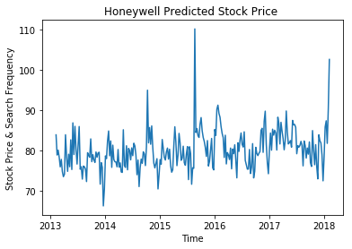

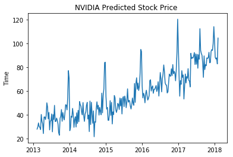

```python
import statsmodels.api as sm
from sklearn.preprocessing import PolynomialFeatures, OneHotEncoder,LabelEncoder
from sklearn.linear_model import LinearRegression
import numpy as np

le = LabelEncoder()
sectors = list(companies['sector'].unique())
enc = OneHotEncoder(categories=[sectors], sparse=False, n_values=len(sectors))
pd.set_option('mode.chained_assignment', 'raise')

X = df[["name_frequency", "symbol_frequency", "sector_frequency"]].copy()

encoded_sectors = enc.fit_transform(df[['sector']]).transpose()
for sector, encoding in zip(sectors,encoded_sectors):
    X[sector] = encoding

poly = PolynomialFeatures(interaction_only=True,include_bias = False)

X2 = poly.fit_transform(X[["name_frequency", 'symbol_frequency', 'sector_frequency']+(sectors)].copy())

reg = LinearRegression(fit_intercept=True).fit(X2,df['price'])


X3 = poly.fit_transform(X.xs('HON')[["name_frequency", 'symbol_frequency', 'sector_frequency']+(sectors)].copy())


fig, axs = plt.subplots(ncols=1)

axs.set_title("Honeywell Predicted Stock Price ")
axs.plot(
    df.xs('HON').index,
    reg.predict(X3),
)
print("Accuracy of model: ".format(reg.score(X3, df.xs('HON')[['price']])))
axs.set_ylabel("Stock Price & Search Frequency")
axs.set_xlabel("Time")

fig, axs = plt.subplots(ncols=1)

X3 = poly.fit_transform(X.xs('NVDA')[["name_frequency", 'symbol_frequency', 'sector_frequency']+(sectors)].copy())

axs.set_title("NVIDIA Predicted Stock Price ")
axs.plot(
    df.xs('NVDA').index,
    reg.predict(X3),
)
print("Accuracy of model: ".format(reg.score(X3, df.xs('NVDA')[['price']])))

axs.set_ylabel("Stock Price & Search Frequency")
axs.set_ylabel("Time")
```

As expected after the initial exploration, the model was not effective in predicting stock prices in the dataset. In fact, the model is so ineffective at predicting stock prices for Honeywell, that it received a score of less than -1.5. The model is significantly worse than simply guessing the average value.

## Conclusion

In the exploration section, we identified a few potentially interesting correlations between company search trends and stock price. However, we were unsuccessful in creating a model that can effectively predict the market given solely this data. This is unsurprising. The stock market is incredibly complex and could not be reasonably expected to be modelled by such a simple formula. The high correlation values observed in NVDA are likely just artifacts of stock prices generally increasing over time. More data and a significantly more complex model is needed to accurately predict market movements. In fact, people make entire [careers](https://en.wikipedia.org/wiki/Quantitative_analyst) and multibillion dollar companies around the pursuit of better market models.